# R Notebook

Installing packages

```r
#install.packages("caTools")
#install.packages("party")
```

Importing libraries

```r
library(dplyr)
library(caTools)
library(party)
library(caret)
```

Importing datasets

Ball by Ball data

```r
data1 <- read.csv("D:/CSE3505/IPL_Ball_by_Ball_2008_2022.csv")
data2 <- read.csv("D:/CSE3505/IPL_Matches_2008_2022.csv")
head(data1)
```

|  | ID | innings | overs | ballnumber | batter | bowler | non.striker | extra_type | batsman_run | extras_run | total_run | non_boundary | isWicketDelivery | player_out | kind | fielders_involved | BattingTeam |
| --- | --- | --- | --- | --- | --- | --- | --- | --- | --- | --- | --- | --- | --- | --- | --- | --- | --- |
| 1 | 1312200 | 1 | 0 | 1 | YBK Jaiswal | Mohammed Shami | JC Buttler | NA | 0 | 0 | 0 | 0 | 0 | NA | NA | NA | Rajasthan Royals |
| 2 | 1312200 | 1 | 0 | 2 | YBK Jaiswal | Mohammed Shami | JC Buttler | legbyes | 0 | 1 | 1 | 0 | 0 | NA | NA | NA | Rajasthan Royals |
| 3 | 1312200 | 1 | 0 | 3 | JC Buttler | Mohammed Shami | YBK Jaiswal | NA | 1 | 0 | 1 | 0 | 0 | NA | NA | NA | Rajasthan Royals |
| 4 | 1312200 | 1 | 0 | 4 | YBK Jaiswal | Mohammed Shami | JC Buttler | NA | 0 | 0 | 0 | 0 | 0 | NA | NA | NA | Rajasthan Royals |
| 5 | 1312200 | 1 | 0 | 5 | YBK Jaiswal | Mohammed Shami | JC Buttler | NA | 0 | 0 | 0 | 0 | 0 | NA | NA | NA | Rajasthan Royals |
| 6 | 1312200 | 1 | 0 | 6 | YBK Jaiswal | Mohammed Shami | JC Buttler | NA | 0 | 0 | 0 | 0 | 0 | NA | NA | NA | Rajasthan Royals |

Dimensions

```r
dim(data1)
```

```
[1] 225954     17
```

Structure

```r
str(data1)
```

```
'data.frame':   225954 obs. of  17 variables:
 $ ID               : int  1312200 1312200 1312200 1312200 1312200 1312200 1312200 1312200 1312200 1312200 ...
 $ innings          : int  1 1 1 1 1 1 1 1 1 1 ...
 $ overs            : int  0 0 0 0 0 0 1 1 1 1 ...
 $ ballnumber       : int  1 2 3 4 5 6 1 2 3 4 ...
 $ batter           : chr  "YBK Jaiswal" "YBK Jaiswal" "JC Buttler" "YBK Jaiswal" ...
 $ bowler           : chr  "Mohammed Shami" "Mohammed Shami" "Mohammed Shami" "Mohammed Shami" ...
 $ non.striker      : chr  "JC Buttler" "JC Buttler" "YBK Jaiswal" "JC Buttler" ...
 $ extra_type       : chr  NA "legbyes" NA NA ...
 $ batsman_run      : int  0 0 1 0 0 0 0 0 4 0 ...
 $ extras_run       : int  0 1 0 0 0 0 0 0 0 0 ...
 $ total_run        : int  0 1 1 0 0 0 0 0 4 0 ...
 $ non_boundary     : int  0 0 0 0 0 0 0 0 0 0 ...
 $ isWicketDelivery : int  0 0 0 0 0 0 0 0 0 0 ...
 $ player_out       : chr  NA NA NA NA ...
 $ kind             : chr  NA NA NA NA ...
 $ fielders_involved: chr  NA NA NA NA ...
 $ BattingTeam      : chr  "Rajasthan Royals" "Rajasthan Royals" "Rajasthan Royals" "Rajasthan Royals" ...
```

Summary

```r
summary(data1)
```

```
       ID             innings          overs          ballnumber       batter             bowler          non.striker
 Min.   : 335982   Min.   :1.000   Min.   : 0.000   Min.   : 1.00   Length:225954      Length:225954      Length:225954
 1st Qu.: 501262   1st Qu.:1.000   1st Qu.: 4.000   1st Qu.: 2.00   Class :character   Class :character   Class :character
 Median : 829737   Median :1.000   Median : 9.000   Median : 4.00   Mode  :character   Mode  :character   Mode  :character
 Mean   : 832047   Mean   :1.484   Mean   : 9.186   Mean   : 3.62
 3rd Qu.:1178395   3rd Qu.:2.000   3rd Qu.:14.000   3rd Qu.: 5.00
 Max.   :1312200   Max.   :6.000   Max.   :19.000   Max.   :10.00
  extra_type         batsman_run      extras_run        total_run     non_boundary      isWicketDelivery   player_out
 Length:225954      Min.   :0.000   Min.   :0.00000   Min.   :0.00   Min.   :0.00e+00   Min.   :0.00000   Length:225954
 Class :character   1st Qu.:0.000   1st Qu.:0.00000   1st Qu.:0.00   1st Qu.:0.00e+00   1st Qu.:0.00000   Class :character
 Mode  :character   Median :1.000   Median :0.00000   Median :1.00   Median :0.00e+00   Median :0.00000   Mode  :character
                    Mean   :1.244   Mean   :0.06691   Mean   :1.31   Mean   :9.29e-05   Mean   :0.04935
                    3rd Qu.:1.000   3rd Qu.:0.00000   3rd Qu.:1.00   3rd Qu.:0.00e+00   3rd Qu.:0.00000
                    Max.   :6.000   Max.   :7.00000   Max.   :7.00   Max.   :1.00e+00   Max.   :1.00000
     kind           fielders_involved  BattingTeam
 Length:225954      Length:225954      Length:225954
 Class :character   Class :character   Class :character
 Mode  :character   Mode  :character   Mode  :character
```

Matches dataset

```r
head(data2)
```

|  | ID | City | Date | Season | MatchNumber | Team1 | Team2 | Venue | TossWinner | TossDecision | SuperOver | WinningTeam | WonBy | Margin | method | Player_of_Match | Team1Players | Team2Players | Umpire1 | Umpire2 |
| --- | --- | --- | --- | --- | --- | --- | --- | --- | --- | --- | --- | --- | --- | --- | --- | --- | --- | --- | --- | --- |
| 1 | 1312200 | Ahmedabad | 2022-05-29 | 2022 | Final | Rajasthan Royals | Gujarat Titans | Narendra Modi Stadium, Ahmedabad | Rajasthan Royals | bat | N | Gujarat Titans | Wickets | 7 | NA | HH Pandya | ['YBK Jaiswal', 'JC Buttler', 'SV Samson', 'D Padikkal', 'SO Hetmyer', 'R Ashwin', 'R Parag', 'TA Boult', 'OC McCoy', 'M Prasidh Krishna', 'YS Chahal'] | ['WP Saha', 'Shubman Gill', 'MS Wade', 'HH Pandya', 'DA Miller', 'R Tewatia', 'Rashid Khan', 'R Sai Kishore', 'LH Ferguson', 'Yash Dayal', 'Mohammed Shami'] | CB Gaffaney | Nitin Menon |
| 2 | 1312199 | Ahmedabad | 2022-05-27 | 2022 | Qualifier 2 | Royal Challengers Bangalore | Rajasthan Royals | Narendra Modi Stadium, Ahmedabad | Rajasthan Royals | field | N | Rajasthan Royals | Wickets | 7 | NA | JC Buttler | ['V Kohli', 'F du Plessis', 'RM Patidar', 'GJ Maxwell', 'MK Lomror', 'KD Karthik', 'Shahbaz Ahmed', 'PWH de Silva', 'HV Patel', 'JR Hazlewood', 'Mohammed Siraj'] | ['YBK Jaiswal', 'JC Buttler', 'SV Samson', 'D Padikkal', 'SO Hetmyer', 'R Parag', 'R Ashwin', 'TA Boult', 'YS Chahal', 'M Prasidh Krishna', 'OC McCoy'] | CB Gaffaney | Nitin Menon |
| 3 | 1312198 | Kolkata | 2022-05-25 | 2022 | Eliminator | Royal Challengers Bangalore | Lucknow Super Giants | Eden Gardens, Kolkata | Lucknow Super Giants | field | N | Royal Challengers Bangalore | Runs | 14 | NA | RM Patidar | ['V Kohli', 'F du Plessis', 'RM Patidar', 'GJ Maxwell', 'MK Lomror', 'KD Karthik', 'Shahbaz Ahmed', 'HV Patel', 'PWH de Silva', 'JR Hazlewood', 'Mohammed Siraj'] | ['Q de Kock', 'KL Rahul', 'M Vohra', 'DJ Hooda', 'MP Stoinis', 'E Lewis', 'KH Pandya', 'PVD Chameera', 'Mohsin Khan', 'Avesh Khan', 'Ravi Bishnoi'] | J Madanagopal | MA Gough |
| 4 | 1312197 | Kolkata | 2022-05-24 | 2022 | Qualifier 1 | Rajasthan Royals | Gujarat Titans | Eden Gardens, Kolkata | Gujarat Titans | field | N | Gujarat Titans | Wickets | 7 | NA | DA Miller | ['YBK Jaiswal', 'JC Buttler', 'SV Samson', 'D Padikkal', 'SO Hetmyer', 'R Parag', 'R Ashwin', 'TA Boult', 'YS Chahal', 'M Prasidh Krishna', 'OC McCoy'] | ['WP Saha', 'Shubman Gill', 'MS Wade', 'HH Pandya', 'DA Miller', 'R Tewatia', 'Rashid Khan', 'R Sai Kishore', 'AS Joseph', 'Yash Dayal', 'Mohammed Shami'] | BNJ Oxenford | VK Sharma |
| 5 | 1304116 | Mumbai | 2022-05-22 | 2022 | 70 | Sunrisers Hyderabad | Punjab Kings | Wankhede Stadium, Mumbai | Sunrisers Hyderabad | bat | N | Punjab Kings | Wickets | 5 | NA | Harpreet Brar | ['PK Garg', 'Abhishek Sharma', 'RA Tripathi', 'AK Markram', 'N Pooran', 'Washington Sundar', 'R Shepherd', 'J Suchith', 'B Kumar', 'Umran Malik', 'Fazalhaq Farooqi'] | ['JM Bairstow', 'S Dhawan', 'M Shahrukh Khan', 'MA Agarwal', 'LS Livingstone', 'JM Sharma', 'PN Mankad', 'Harpreet Brar', 'K Rabada', 'NT Ellis', 'Arshdeep Singh'] | AK Chaudhary | NA Patwardhan |
| 6 | 1304115 | Mumbai | 2022-05-21 | 2022 | 69 | Delhi Capitals | Mumbai Indians | Wankhede Stadium, Mumbai | Mumbai Indians | field | N | Mumbai Indians | Wickets | 5 | NA | JJ Bumrah | ['PP Shaw', 'DA Warner', 'MR Marsh', 'RR Pant', 'SN Khan', 'R Powell', 'AR Patel', 'SN Thakur', 'Kuldeep Yadav', 'A Nortje', 'KK Ahmed'] | ['Ishan Kishan', 'RG Sharma', 'D Brevis', 'Tilak Varma', 'TH David', 'Ramandeep Singh', 'DR Sams', 'HR Shokeen', 'JJ Bumrah', 'M Markande', 'RP Meredith'] | Nitin Menon | Tapan Sharma |

Dimensions

```r
dim(data2)
```

```
[1] 950  20
```

Structure

```r
str(data2)
```

```
'data.frame':   950 obs. of  20 variables:
 $ ID             : int  1312200 1312199 1312198 1312197 1304116 1304115 1304114 1304113 1304112 1304111 ...
 $ City           : chr  "Ahmedabad" "Ahmedabad" "Kolkata" "Kolkata" ...
 $ Date           : chr  "2022-05-29" "2022-05-27" "2022-05-25" "2022-05-24" ...
 $ Season         : chr  "2022" "2022" "2022" "2022" ...
 $ MatchNumber    : chr  "Final" "Qualifier 2" "Eliminator" "Qualifier 1" ...
 $ Team1          : chr  "Rajasthan Royals" "Royal Challengers Bangalore" "Royal Challengers Bangalore" "Rajasthan Royals" ...
 $ Team2          : chr  "Gujarat Titans" "Rajasthan Royals" "Lucknow Super Giants" "Gujarat Titans" ...
 $ Venue          : chr  "Narendra Modi Stadium, Ahmedabad" "Narendra Modi Stadium, Ahmedabad" "Eden Gardens, Kolkata" "Eden Gardens, Kolkata" ...
 $ TossWinner     : chr  "Rajasthan Royals" "Rajasthan Royals" "Lucknow Super Giants" "Gujarat Titans" ...
 $ TossDecision   : chr  "bat" "field" "field" "field" ...
 $ SuperOver      : chr  "N" "N" "N" "N" ...
 $ WinningTeam    : chr  "Gujarat Titans" "Rajasthan Royals" "Royal Challengers Bangalore" "Gujarat Titans" ...
 $ WonBy          : chr  "Wickets" "Wickets" "Runs" "Wickets" ...
 $ Margin         : int  7 7 14 7 5 5 5 8 2 3 ...
 $ method         : chr  NA NA NA NA ...
 $ Player_of_Match: chr  "HH Pandya" "JC Buttler" "RM Patidar" "DA Miller" ...
 $ Team1Players   : chr  "['YBK Jaiswal', 'JC Buttler', 'SV Samson', 'D Padikkal', 'SO Hetmyer', 'R Ashwin', 'R Parag', 'TA Boult', 'OC M"| __truncated__ "['V Kohli', 'F du Plessis', 'RM Patidar', 'GJ Maxwell', 'MK Lomror', 'KD Karthik', 'Shahbaz Ahmed', 'PWH de Sil"| __truncated__ "['V Kohli', 'F d…
 $ Team2Players   : chr  "['WP Saha', 'Shubman Gill', 'MS Wade', 'HH Pandya', 'DA Miller', 'R Tewatia', 'Rashid Khan', 'R Sai Kishore', '"| __truncated__ "['YBK Jaiswal', 'JC Buttler', 'SV Samson', 'D Padikkal', 'SO Hetmyer', 'R Parag', 'R Ashwin', 'TA Boult', 'YS C"| __truncated__ "['Q de Kock', 'K…
 $ Umpire1        : chr  "CB Gaffaney" "CB Gaffaney" "J Madanagopal" "BNJ Oxenford" ...
 $ Umpire2        : chr  "Nitin Menon" "Nitin Menon" "MA Gough" "VK Sharma" ...
```

Summary

```r
summary(data2)
```

```
       ID              City               Date              Season          MatchNumber           Team1
 Min.   : 335982   Length:950         Length:950         Length:950         Length:950         Length:950
 1st Qu.: 501261   Class :character   Class :character   Class :character   Class :character   Class :character
 Median : 829738   Mode  :character   Mode  :character   Mode  :character   Mode  :character   Mode  :character
 Mean   : 830485
 3rd Qu.:1175372
 Max.   :1312200

    Team2              Venue            TossWinner        TossDecision        SuperOver         WinningTeam
 Length:950         Length:950         Length:950         Length:950         Length:950         Length:950
 Class :character   Class :character   Class :character   Class :character   Class :character   Class :character
 Mode  :character   Mode  :character   Mode  :character   Mode  :character   Mode  :character   Mode  :character




    WonBy               Margin          method          Player_of_Match    Team1Players       Team2Players
 Length:950         Min.   :  1.00   Length:950         Length:950         Length:950         Length:950
 Class :character   1st Qu.:  6.00   Class :character   Class :character   Class :character   Class :character
 Mode  :character   Median :  8.00   Mode  :character   Mode  :character   Mode  :character   Mode  :character
                    Mean   : 17.06
                    3rd Qu.: 19.00
                    Max.   :146.00
                    NA's   :18
   Umpire1            Umpire2
 Length:950         Length:950
 Class :character   Class :character
 Mode  :character   Mode  :character
```

Getting the total scores by grouping balls bowled in each match by the ID and summing the total_run attribute

```r
totals <- data1 %>% group_by(ID, innings,BattingTeam) %>% summarise(score=sum(total_run))
head(totals)
```

| ID | innings | BattingTeam | score |
| --- | --- | --- | --- |
| 335982 | 1 | Kolkata Knight Riders | 222 |
| 335982 | 2 | Royal Challengers Bangalore | 82 |
| 335983 | 1 | Chennai Super Kings | 240 |
| 335983 | 2 | Kings XI Punjab | 207 |
| 335984 | 1 | Rajasthan Royals | 129 |
| 335984 | 2 | Delhi Daredevils | 132 |

Filtering to get only first innings score for predicting win and adding 1 to get the target score

```r
firstinnings <- filter(totals,innings==1)
firstinnings['target'] <- firstinnings['score']+1
head(firstinnings)
```

| ID | innings | BattingTeam | score | target |
| --- | --- | --- | --- | --- |
| 335982 | 1 | Kolkata Knight Riders | 222 | 223 |
| 335983 | 1 | Chennai Super Kings | 240 | 241 |
| 335984 | 1 | Rajasthan Royals | 129 | 130 |
| 335985 | 1 | Mumbai Indians | 165 | 166 |
| 335986 | 1 | Deccan Chargers | 110 | 111 |
| 335987 | 1 | Kings XI Punjab | 166 | 167 |

Merging the target with our matches dataset to generate a dataset with a predictor value for prediction using ML algorithms

```r
ipl <- merge(data2,firstinnings,by="ID")
ipl <- subset(ipl,select=-c(innings,score))
ipl$result <- ifelse(ipl$WinningTeam == ipl$BattingTeam,"Won","Lost") #Predictor
iplcopy<-ipl
head(ipl)
```

|  | ID | City | Date | Season | MatchNumber | Team1 | Team2 | Venue | TossWinner | TossDecision | SuperOver | WinningTeam | WonBy | Margin | method | Player_of_Match | Team1Players | Team2Players | Umpire1 | Umpire2 | BattingTeam | target | result |
| --- | --- | --- | --- | --- | --- | --- | --- | --- | --- | --- | --- | --- | --- | --- | --- | --- | --- | --- | --- | --- | --- | --- | --- |
| 1 | 335982 | Bangalore | 2008-04-18 | 2007/08 | 1 | Royal Challengers Bangalore | Kolkata Knight Riders | M Chinnaswamy Stadium | Royal Challengers Bangalore | field | N | Kolkata Knight Riders | Runs | 140 | NA | BB McCullum | ['R Dravid', 'W Jaffer', 'V Kohli', 'JH Kallis', 'CL White', 'MV Boucher', 'B Akhil', 'AA Noffke', 'P Kumar', 'Z Khan', 'SB Joshi'] | ['SC Ganguly', 'BB McCullum', 'RT Ponting', 'DJ Hussey', 'Mohammad Hafeez', 'LR Shukla', 'WP Saha', 'AB Agarkar', 'AB Dinda', 'M Kartik', 'I Sharma'] | Asad Rauf | RE Koertzen | Kolkata Knight Riders | 223 | Won |
| 2 | 335983 | Chandigarh | 2008-04-19 | 2007/08 | 2 | Kings XI Punjab | Chennai Super Kings | Punjab Cricket Association Stadium, Mohali | Chennai Super Kings | bat | N | Chennai Super Kings | Runs | 33 | NA | MEK Hussey | ['K Goel', 'JR Hopes', 'KC Sangakkara', 'Yuvraj Singh', 'SM Katich', 'IK Pathan', 'P Dharmani', 'B Lee', 'PP Chawla', 'WA Mota', 'S Sreesanth'] | ['PA Patel', 'ML Hayden', 'MEK Hussey', 'MS Dhoni', 'SK Raina', 'JDP Oram', 'S Badrinath', 'Joginder Sharma', 'P Amarnath', 'MS Gony', 'M Muralitharan'] | MR Benson | SL Shastri | Chennai Super Kings | 241 | Won |
| 3 | 335984 | Delhi | 2008-04-19 | 2007/08 | 3 | Delhi Daredevils | Rajasthan Royals | Feroz Shah Kotla | Rajasthan Royals | bat | N | Delhi Daredevils | Wickets | 9 | NA | MF Maharoof | ['G Gambhir', 'V Sehwag', 'S Dhawan', 'MK Tiwary', 'KD Karthik', 'R Bhatia', 'M Manhas', 'DL Vettori', 'MF Maharoof', 'B Geeves', 'GD McGrath'] | ['T Kohli', 'YK Pathan', 'SR Watson', 'M Kaif', 'DS Lehmann', 'RA Jadeja', 'M Rawat', 'D Salunkhe', 'SK Warne', 'SK Trivedi', 'MM Patel'] | Aleem Dar | GA Pratapkumar | Rajasthan Royals | 130 | Lost |
| 4 | 335985 | Mumbai | 2008-04-20 | 2007/08 | 5 | Mumbai Indians | Royal Challengers Bangalore | Wankhede Stadium | Mumbai Indians | bat | N | Royal Challengers Bangalore | Wickets | 5 | NA | MV Boucher | ['L Ronchi', 'ST Jayasuriya', 'DJ Thornely', 'RV Uthappa', 'PR Shah', 'AM Nayar', 'SM Pollock', 'Harbhajan Singh', 'MA Khote', 'A Nehra', 'DS Kulkarni'] | ['S Chanderpaul', 'R Dravid', 'LRPL Taylor', 'JH Kallis', 'V Kohli', 'MV Boucher', 'B Akhil', 'P Kumar', 'Z Khan', 'SB Joshi', 'R Vinay Kumar'] | SJ Davis | DJ Harper | Mumbai Indians | 166 | Lost |
| 5 | 335986 | Kolkata | 2008-04-20 | 2007/08 | 4 | Kolkata Knight Riders | Deccan Chargers | Eden Gardens | Deccan Chargers | bat | N | Kolkata Knight Riders | Wickets | 5 | NA | DJ Hussey | ['WP Saha', 'BB McCullum', 'RT Ponting', 'SC Ganguly', 'DJ Hussey', 'Mohammad Hafeez', 'LR Shukla', 'AB Agarkar', 'AB Dinda', 'M Kartik', 'I Sharma'] | ['AC Gilchrist', 'Y Venugopal Rao', 'VVS Laxman', 'A Symonds', 'RG Sharma', 'SB Styris', 'AS Yadav', 'SB Bangar', 'WPUJC Vaas', 'RP Singh', 'PP Ojha'] | BF Bowden | K Hariharan | Deccan Chargers | 111 | Lost |
| 6 | 335987 | Jaipur | 2008-04-21 | 2007/08 | 6 | Rajasthan Royals | Kings XI Punjab | Sawai Mansingh Stadium | Kings XI Punjab | bat | N | Rajasthan Royals | Wickets | 6 | NA | SR Watson | ['M Kaif', 'Kamran Akmal', 'YK Pathan', 'SR Watson', 'DS Lehmann', 'RA Jadeja', 'Pankaj Singh', 'D Salunkhe', 'SK Warne', 'SK Trivedi', 'MM Patel'] | ['K Goel', 'JR Hopes', 'KC Sangakkara', 'DPMD Jayawardene', 'Yuvraj Singh', 'IK Pathan', 'S Sohal', 'B Lee', 'PP Chawla', 'WA Mota', 'S Sreesanth'] | Aleem Dar | RB Tiffin | Kings XI Punjab | 167 | Lost |

Imputing no result for NA columns in result

```r
colSums(is.na(ipl))
```

```
             ID            City            Date          Season     MatchNumber           Team1           Team2           Venue
              0              51               0               0               0               0               0               0
     TossWinner    TossDecision       SuperOver     WinningTeam           WonBy          Margin          method Player_of_Match
              0               0               4               4               0              18             931               4
   Team1Players    Team2Players         Umpire1         Umpire2     BattingTeam          target          result
              0               0               0               0               0               0               4
```

Removing trivial features like Won By, Margin which will give out answer of result of the match and other irrelevent features

```r
ipl <- subset(ipl,select=-c(ID,City,Date,MatchNumber,WinningTeam,WonBy,Margin,method,Umpire1,Umpire2))
head(ipl)
```

|  | Season | Team1 | Team2 | Venue | TossWinner | TossDecision | SuperOver | Player_of_Match | Team1Players | Team2Players | BattingTeam | target | result |
| --- | --- | --- | --- | --- | --- | --- | --- | --- | --- | --- | --- | --- | --- |
| 1 | 2007/08 | Royal Challengers Bangalore | Kolkata Knight Riders | M Chinnaswamy Stadium | Royal Challengers Bangalore | field | N | BB McCullum | ['R Dravid', 'W Jaffer', 'V Kohli', 'JH Kallis', 'CL White', 'MV Boucher', 'B Akhil', 'AA Noffke', 'P Kumar', 'Z Khan', 'SB Joshi'] | ['SC Ganguly', 'BB McCullum', 'RT Ponting', 'DJ Hussey', 'Mohammad Hafeez', 'LR Shukla', 'WP Saha', 'AB Agarkar', 'AB Dinda', 'M Kartik', 'I Sharma'] | Kolkata Knight Riders | 223 | Won |
| 2 | 2007/08 | Kings XI Punjab | Chennai Super Kings | Punjab Cricket Association Stadium, Mohali | Chennai Super Kings | bat | N | MEK Hussey | ['K Goel', 'JR Hopes', 'KC Sangakkara', 'Yuvraj Singh', 'SM Katich', 'IK Pathan', 'P Dharmani', 'B Lee', 'PP Chawla', 'WA Mota', 'S Sreesanth'] | ['PA Patel', 'ML Hayden', 'MEK Hussey', 'MS Dhoni', 'SK Raina', 'JDP Oram', 'S Badrinath', 'Joginder Sharma', 'P Amarnath', 'MS Gony', 'M Muralitharan'] | Chennai Super Kings | 241 | Won |
| 3 | 2007/08 | Delhi Daredevils | Rajasthan Royals | Feroz Shah Kotla | Rajasthan Royals | bat | N | MF Maharoof | ['G Gambhir', 'V Sehwag', 'S Dhawan', 'MK Tiwary', 'KD Karthik', 'R Bhatia', 'M Manhas', 'DL Vettori', 'MF Maharoof', 'B Geeves', 'GD McGrath'] | ['T Kohli', 'YK Pathan', 'SR Watson', 'M Kaif', 'DS Lehmann', 'RA Jadeja', 'M Rawat', 'D Salunkhe', 'SK Warne', 'SK Trivedi', 'MM Patel'] | Rajasthan Royals | 130 | Lost |
| 4 | 2007/08 | Mumbai Indians | Royal Challengers Bangalore | Wankhede Stadium | Mumbai Indians | bat | N | MV Boucher | ['L Ronchi', 'ST Jayasuriya', 'DJ Thornely', 'RV Uthappa', 'PR Shah', 'AM Nayar', 'SM Pollock', 'Harbhajan Singh', 'MA Khote', 'A Nehra', 'DS Kulkarni'] | ['S Chanderpaul', 'R Dravid', 'LRPL Taylor', 'JH Kallis', 'V Kohli', 'MV Boucher', 'B Akhil', 'P Kumar', 'Z Khan', 'SB Joshi', 'R Vinay Kumar'] | Mumbai Indians | 166 | Lost |
| 5 | 2007/08 | Kolkata Knight Riders | Deccan Chargers | Eden Gardens | Deccan Chargers | bat | N | DJ Hussey | ['WP Saha', 'BB McCullum', 'RT Ponting', 'SC Ganguly', 'DJ Hussey', 'Mohammad Hafeez', 'LR Shukla', 'AB Agarkar', 'AB Dinda', 'M Kartik', 'I Sharma'] | ['AC Gilchrist', 'Y Venugopal Rao', 'VVS Laxman', 'A Symonds', 'RG Sharma', 'SB Styris', 'AS Yadav', 'SB Bangar', 'WPUJC Vaas', 'RP Singh', 'PP Ojha'] | Deccan Chargers | 111 | Lost |
| 6 | 2007/08 | Rajasthan Royals | Kings XI Punjab | Sawai Mansingh Stadium | Kings XI Punjab | bat | N | SR Watson | ['M Kaif', 'Kamran Akmal', 'YK Pathan', 'SR Watson', 'DS Lehmann', 'RA Jadeja', 'Pankaj Singh', 'D Salunkhe', 'SK Warne', 'SK Trivedi', 'MM Patel'] | ['K Goel', 'JR Hopes', 'KC Sangakkara', 'DPMD Jayawardene', 'Yuvraj Singh', 'IK Pathan', 'S Sohal', 'B Lee', 'PP Chawla', 'WA Mota', 'S Sreesanth'] | Kings XI Punjab | 167 | Lost |

Imputing fields of NA in result by a constant text (Classifying feature cannot have NA values)

```r
ipl$result[is.na(ipl$result)] = "No result"
```

Checking NA values

```r
colSums(is.na(ipl))
```

```
         Season           Team1           Team2           Venue      TossWinner    TossDecision       SuperOver Player_of_Match
              0               0               0               0               0               0               4               4
   Team1Players    Team2Players     BattingTeam          target          result
              0               0               0               0               0
```

Label Encoding by making all categorical features as numeric

```r
ipl$Season <- as.numeric(factor(ipl$Season))
ipl$Team1 <- as.numeric(factor(ipl$Team1))
ipl$Team2 <- as.numeric(factor(ipl$Team2))
ipl$Venue <- as.numeric(factor(ipl$Venue))
ipl$TossWinner <- as.numeric(factor(ipl$TossWinner))
ipl$TossDecision <- as.numeric(factor(ipl$TossDecision))
ipl$SuperOver <- as.numeric(factor(ipl$SuperOver))
ipl$Player_of_Match <- as.numeric(factor(ipl$Player_of_Match))
ipl$Team1Players <- as.numeric(factor(ipl$Team1Players))
ipl$Team2Players <- as.numeric(factor(ipl$Team2Players))
ipl$BattingTeam <- as.numeric(factor(ipl$BattingTeam))
ipl$result <- as.numeric(factor(ipl$result))
head(ipl)
```

|  | Season | Team1 | Team2 | Venue | TossWinner | TossDecision | SuperOver | Player_of_Match | Team1Players | Team2Players | BattingTeam | target | result |
| --- | --- | --- | --- | --- | --- | --- | --- | --- | --- | --- | --- | --- | --- |
| 1 | 1 | 17 | 9 | 20 | 17 | 2 | 1 | 34 | 663 | 785 | 9 | 223 | 3 |
| 2 | 1 | 7 | 1 | 34 | 1 | 1 | 1 | 140 | 378 | 568 | 1 | 241 | 3 |
| 3 | 1 | 4 | 14 | 14 | 14 | 1 | 1 | 141 | 292 | 877 | 14 | 130 | 1 |
| 4 | 1 | 11 | 17 | 47 | 11 | 1 | 1 | 163 | 413 | 748 | 11 | 166 | 1 |
| 5 | 1 | 9 | 2 | 12 | 2 | 1 | 1 | 53 | 912 | 47 | 2 | 111 | 1 |
| 6 | 1 | 14 | 7 | 39 | 7 | 1 | 1 | 238 | 428 | 380 | 7 | 167 | 1 |

```r
corr_mat <- round(cor(ipl),2)
corr_mat = as.data.frame(corr_mat)
head(corr_mat)
```

|  | Season | Team1 | Team2 | Venue | TossWinner | TossDecision | SuperOver | Player_of_Match | Team1Players | Team2Players | BattingTeam | target | result |
| --- | --- | --- | --- | --- | --- | --- | --- | --- | --- | --- | --- | --- | --- |
| Season | 1.00 | 0.16 | 0.12 | 0.00 | 0.15 | 0.24 | NA | NA | 0.14 | 0.07 | 0.18 | 0.14 | 0.00 |
| Team1 | 0.16 | 1.00 | -0.11 | 0.13 | 0.34 | 0.11 | NA | NA | -0.10 | 0.02 | 0.68 | -0.03 | -0.05 |
| Team2 | 0.12 | -0.11 | 1.00 | 0.02 | 0.56 | -0.01 | NA | NA | 0.03 | -0.10 | 0.22 | 0.02 | 0.06 |
| Venue | 0.00 | 0.13 | 0.02 | 1.00 | 0.05 | -0.04 | NA | NA | 0.01 | 0.05 | 0.10 | -0.05 | -0.02 |
| TossWinner | 0.15 | 0.34 | 0.56 | 0.05 | 1.00 | 0.07 | NA | NA | 0.00 | -0.06 | 0.33 | -0.03 | -0.01 |
| TossDecision | 0.24 | 0.11 | -0.01 | -0.04 | 0.07 | 1.00 | NA | NA | -0.02 | -0.02 | 0.09 | 0.10 | -0.01 |

```r
ipl <- subset(ipl,select=-c(SuperOver,Player_of_Match))
```

Viewing the dimensionality reduced and label encoded dataset

```r
head(ipl)
```

|  | Season | Team1 | Team2 | Venue | TossWinner | TossDecision | Team1Players | Team2Players | BattingTeam | target | result |
| --- | --- | --- | --- | --- | --- | --- | --- | --- | --- | --- | --- |
| 1 | 1 | 17 | 9 | 20 | 17 | 2 | 663 | 785 | 9 | 223 | 3 |
| 2 | 1 | 7 | 1 | 34 | 1 | 1 | 378 | 568 | 1 | 241 | 3 |
| 3 | 1 | 4 | 14 | 14 | 14 | 1 | 292 | 877 | 14 | 130 | 1 |
| 4 | 1 | 11 | 17 | 47 | 11 | 1 | 413 | 748 | 11 | 166 | 1 |
| 5 | 1 | 9 | 2 | 12 | 2 | 1 | 912 | 47 | 2 | 111 | 1 |
| 6 | 1 | 14 | 7 | 39 | 7 | 1 | 428 | 380 | 7 | 167 | 1 |

Splitting data into training and testing data

```r
ipl$result<-factor(ipl$result)
sample_data = sample.split(ipl, SplitRatio = 0.8)
train_data <- subset(ipl, sample_data == TRUE)
test_data <- subset(ipl, sample_data == FALSE)
```

Fitting and plotting decision tree model

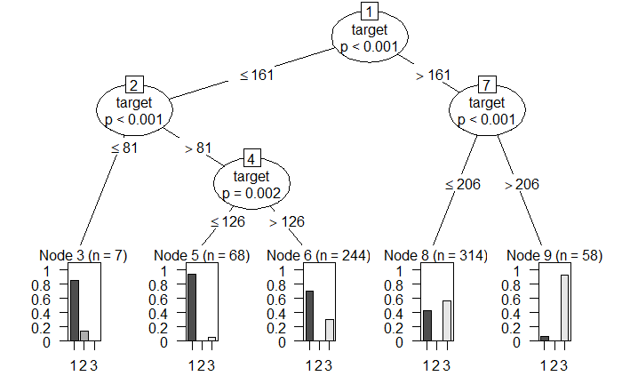

```r
model<- ctree(result ~ ., train_data)
plot(model)
```

Using test data for prediction and creating a confusion matrix

```r
model_predict <-predict(model, test_data)
confusionmat<- table(test_data$result, model_predict)
confusionmat
```

```
   model_predict
     1  2  3
  1 82  0 59
  2  1  0  0
  3 31  0 86
```

Accuracy of the model

```r
accuracy <- sum(diag(confusionmat)) / sum(confusionmat)
print(paste('Accuracy for test is ', accuracy))
```

```
[1] "Accuracy for test is  0.648648648648649"
```

All evaluation metrics for decision tree

```r
confusionMatrix(confusionmat)
```

```
Confusion Matrix and Statistics

   model_predict
     1  2  3
  1 82  0 59
  2  1  0  0
  3 31  0 86

Overall Statistics

               Accuracy : 0.6486
                 95% CI : (0.5871, 0.7067)
    No Information Rate : 0.5598
    P-Value [Acc > NIR] : 0.002251

                  Kappa : 0.3076

 Mcnemar's Test P-Value : NA

Statistics by Class:

                     Class: 1 Class: 2 Class: 3
Sensitivity            0.7193       NA   0.5931
Specificity            0.5931 0.996139   0.7281
Pos Pred Value         0.5816       NA   0.7350
Neg Pred Value         0.7288       NA   0.5845
Prevalence             0.4402 0.000000   0.5598
Detection Rate         0.3166 0.000000   0.3320
Detection Prevalence   0.5444 0.003861   0.4517
Balanced Accuracy      0.6562       NA   0.6606
```